# CIND 123: Data Analytics Basic Methods: Assignment-3_F2022

# Assignment 3 (10%)

## Total 100 Marks

### [DK0]

# Instructions

Use RStudio for this assignment. Complete the assignment by inserting your code wherever you see the string “#INSERT YOUR ANSWER HERE”.

**NOTE**: YOU SHOULD NEVER HAVE `install.packages` IN YOUR CODE; OTHERWISE, THE `Knit` OPTION WILL GIVE AN ERROR. COMMENT OUT ALL PACKAGE INSTALLATIONS.

Submit **both** the `rmd` and generated `output` files. Failing to submit both files will be subject to mark deduction. PDF or HTML is preferred.

## Sample Question and Solution

Use `seq()` to create the vector $(3, 5, \dots, 29)$.

```r
seq(3, 30, 2)
```

```
##  [1]  3  5  7  9 11 13 15 17 19 21 23 25 27 29
```

```r
seq(3, 29, 2)
```

```
##  [1]  3  5  7  9 11 13 15 17 19 21 23 25 27 29
```

# Question 1 [30 Pts]

## Q1a (10 points)

Suppose you have a dataset with two variables, age (c(41, 56, 45, 65, 25, 70, 30, 33, 60, 35)) and income (c(93000, 110000, 80000, 125000, 40000, 145000, 78000, 51000, 110000, 69000)), for a sample of 10 individuals. The `age` variable represents the age of the individual, while the `income` variable represents their annual income. Set variables age and income respectively. Then find the least-squares line relating the `age` to the `income`.

Does the assumption of a linear relationship appear to be reasonable in this case? Give reasons for your answer as a comment.

```r
age <- c(41, 56, 45, 65, 25, 70, 30, 33, 60, 35)
income <- c(93000, 110000, 80000, 125000, 40000, 145000, 78000, 51000, 110000, 69000)
dataset <- data.frame(age,income)
dataset
```

```
##    age income
## 1   41  93000
## 2   56 110000
## 3   45  80000
## 4   65 125000
## 5   25  40000
## 6   70 145000
## 7   30  78000
## 8   33  51000
## 9   60 110000
## 10  35  69000
```

```r
model <- lm(income ~ age,data=dataset)
model
```

```
##
## Call:
## lm(formula = income ~ age, data = dataset)
##
## Coefficients:
## (Intercept)          age
##        -835         1977
```

```r
summary(model)
```

```
##
## Call:
## lm(formula = income ~ age, data = dataset)
##
## Residuals:
##    Min     1Q Median     3Q    Max
## -13401  -8036  -1264   5753  19530
##
## Coefficients:
##             Estimate Std. Error t value Pr(>|t|)
## (Intercept)   -835.0    11342.9  -0.074    0.943
## age           1976.8      234.5   8.432 2.99e-05 ***
## ---
## Signif. codes:  0 '***' 0.001 '**' 0.01 '*' 0.05 '.' 0.1 ' ' 1
##
## Residual standard error: 11110 on 8 degrees of freedom
## Multiple R-squared:  0.8989, Adjusted R-squared:  0.8862
## F-statistic: 71.09 on 1 and 8 DF,  p-value: 2.986e-05
```

```r
#######Does the assumption of a linear relationship appear to be reasonable in this case?

#Income = -835.0 + 1976.8 * age
###This linear regression model shows a positive relationship between age and income. The coefficient for age is estimated to be 1976.8, meaning that for every one-year increase in age, income increases by $1,976.8 so age is a significant predictor of income. The intercept of this model is -835.0.  In the context of the data, a negative intercept of -835 implies that income is negative for newborns and people at age 0.This model assumes a linear relationship between income and age, which might not be appropriate in every case.It is important  to consider additional factors that may affect the relationship between age and income.
```

## Q1b (10 points)

Plot the income as a function of age using a scatterplot and draw the least-square line on the same plot.

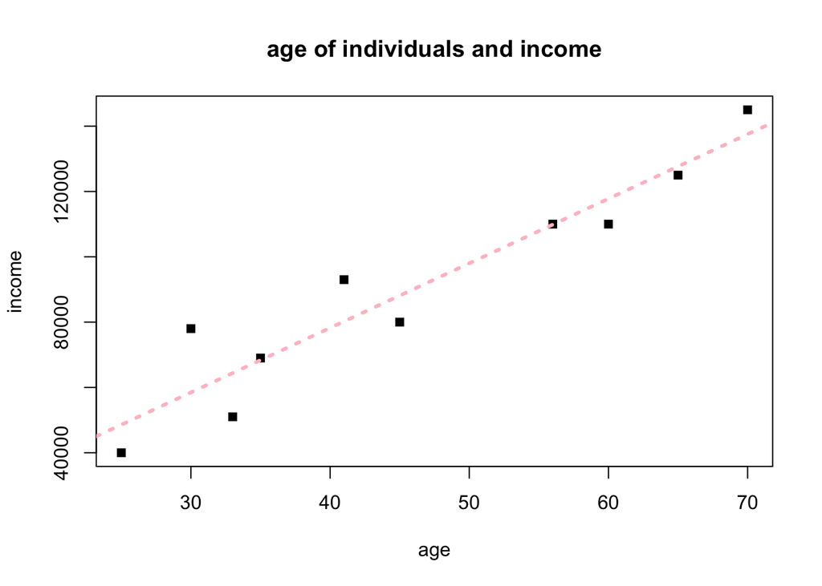

```r
plot(age,income, pch=15,
xlab="age",
ylab="income",
main="age of individuals and income")
abline(coefficients(model), lwd=3, lty=3, col="pink")
```

## Q1c (10 points)

Use the regression line to predict the income when the age is 38.

```r
age_predict <-38
#income_predict<- intercept+slope*age_predict
#income_predict

income_predict<- -835.00+1976.8*38
income_predict
```

```
## [1] 74283.4
```

# Question 2 [45 Pts]

Please load the OpenIntro Statistics Dataset - loans_full_schema data by running the following chunk of code.

You can read more about at this link: - https://r-data.pmagunia.com/dataset/openintro-statistics-dataset-loansfullschema - https://www.openintro.org/data/index.php?data=loans_full_schema

```r
OpenIntro = read.csv("https://r-data.pmagunia.com/system/files/datasets/dataset-100644960.csv")
```

## Q2a (5 points)

Display the first 5 rows of the `OpenIntro` data, the names of all the variables, and a descriptive summary of each variable.

```r
head(OpenIntro, n=5)
```

```
##                 emp_title emp_length state homeownership annual_income
## 1 global config engineer           3    NJ      MORTGAGE         90000
## 2  warehouse office clerk         10    HI          RENT         40000
## 3                assembly          3    WI          RENT         40000
## 4        customer service          1    PA          RENT         30000
## 5    security supervisor          10    CA          RENT         35000
##   verified_income debt_to_income annual_income_joint verification_income_joint
## 1        Verified          18.01                  NA
## 2    Not Verified           5.04                  NA
## 3 Source Verified          21.15                  NA
## 4    Not Verified          10.16                  NA
## 5        Verified          57.96               57000                  Verified
##   debt_to_income_joint delinq_2y months_since_last_delinq earliest_credit_line
## 1                   NA         0                       38                 2001
## 2                   NA         0                       NA                 1996
```

[output cut: 81 more lines]

```r
# Print the names of all the variables
 names(OpenIntro)
```

```
##  [1] "emp_title"                        "emp_length"
##  [3] "state"                            "homeownership"
##  [5] "annual_income"                    "verified_income"
##  [7] "debt_to_income"                   "annual_income_joint"
##  [9] "verification_income_joint"        "debt_to_income_joint"
## [11] "delinq_2y"                        "months_since_last_delinq"
## [13] "earliest_credit_line"             "inquiries_last_12m"
## [15] "total_credit_lines"               "open_credit_lines"
## [17] "total_credit_limit"               "total_credit_utilized"
## [19] "num_collections_last_12m"         "num_historical_failed_to_pay"
## [21] "months_since_90d_late"            "current_accounts_delinq"
## [23] "total_collection_amount_ever"     "current_installment_accounts"
## [25] "accounts_opened_24m"              "months_since_last_credit_inquiry"
## [27] "num_satisfactory_accounts"        "num_accounts_120d_past_due"
## [29] "num_accounts_30d_past_due"        "num_active_debit_accounts"
## [31] "total_debit_limit"                "num_total_cc_accounts"
## [33] "num_open_cc_accounts"             "num_cc_carrying_balance"
## [35] "num_mort_accounts"                "account_never_delinq_percent"
## [37] "tax_liens"                        "public_record_bankrupt"
## [39] "loan_purpose"                     "application_type"
## [41] "loan_amount"                      "term"
## [43] "interest_rate"                    "installment"
## [45] "grade"                            "sub_grade"
## [47] "issue_month"                      "loan_status"
## [49] "initial_listing_status"           "disbursement_method"
## [51] "balance"                          "paid_total"
## [53] "paid_principal"                   "paid_interest"
## [55] "paid_late_fees"
```

```r
# Print a descriptive summary of each variable
 summary(OpenIntro)
```

```
##   emp_title           emp_length       state           homeownership
##  Length:10000       Min.   : 0.00   Length:10000       Length:10000
##  Class :character   1st Qu.: 2.00   Class :character   Class :character
##  Mode  :character   Median : 6.00   Mode  :character   Mode  :character
##                     Mean   : 5.93
##                     3rd Qu.:10.00
##                     Max.   :10.00
##                     NA's   :817
##  annual_income     verified_income    debt_to_income   annual_income_joint
##  Min.   :      0   Length:10000       Min.   :  0.00   Min.   :  19200
##  1st Qu.:  45000   Class :character   1st Qu.: 11.06   1st Qu.:  86834
##  Median :  65000   Mode  :character   Median : 17.57   Median : 113000
##  Mean   :  79222                      Mean   : 19.31   Mean   : 127915
##  3rd Qu.:  95000                      3rd Qu.: 25.00   3rd Qu.: 151546
##  Max.   :2300000                      Max.   :469.09   Max.   :1100000
##                                       NA's   :24       NA's   :8505
##  verification_income_joint debt_to_income_joint   delinq_2y
##  Length:10000              Min.   : 0.32        Min.   : 0.000
##  Class :character          1st Qu.:14.16        1st Qu.: 0.000
##  Mode  :character          Median :19.72        Median : 0.000
##                            Mean   :19.98        Mean   : 0.216
##                            3rd Qu.:25.50        3rd Qu.: 0.000
##                            Max.   :39.98        Max.   :13.000
##                            NA's   :8505
##  months_since_last_delinq earliest_credit_line inquiries_last_12m
##  Min.   :  1.00           Min.   :1963         Min.   : 0.000
##  1st Qu.: 19.00           1st Qu.:1997         1st Qu.: 0.000
##  Median : 34.00           Median :2003         Median : 1.000
##  Mean   : 36.76           Mean   :2001         Mean   : 1.958
##  3rd Qu.: 53.00           3rd Qu.:2006         3rd Qu.: 3.000
##  Max.   :118.00           Max.   :2015         Max.   :29.000
##  NA's   :5658
##  total_credit_lines open_credit_lines total_credit_limit total_credit_utilized
##  Min.   : 2.00      Min.   : 0.0      Min.   :      0    Min.   :     0
##  1st Qu.:14.00      1st Qu.: 7.0      1st Qu.:  51594    1st Qu.: 19186
##  Median :21.00      Median :10.0      Median : 114667    Median : 36927
##  Mean   :22.68      Mean   :11.4      Mean   : 183606    Mean   : 51049
##  3rd Qu.:29.00      3rd Qu.:14.0      3rd Qu.: 267550    3rd Qu.: 65421
##  Max.   :87.00      Max.   :51.0      Max.   :3386034    Max.   :942456
##
```

[output cut: 81 more lines]

```
##  Length:10000           Length:10000        Min.   :    0   Min.   :    0.0
##  Class :character       Class :character    1st Qu.: 6679   1st Qu.:  928.7
##  Mode  :character       Mode  :character    Median :12380   Median : 1563.3
##                                             Mean   :14459   Mean   : 2494.2
##                                             3rd Qu.:20690   3rd Qu.: 2616.0
##                                             Max.   :40000   Max.   :41630.4
##
##  paid_principal    paid_interest    paid_late_fees
##  Min.   :    0.0   Min.   :   0.0   Min.   : 0.0000
##  1st Qu.:  587.1   1st Qu.: 221.8   1st Qu.: 0.0000
##  Median :  985.0   Median : 446.1   Median : 0.0000
##  Mean   : 1894.5   Mean   : 599.7   Mean   : 0.1195
##  3rd Qu.: 1694.6   3rd Qu.: 825.4   3rd Qu.: 0.0000
##  Max.   :40000.0   Max.   :4216.4   Max.   :52.9800
##
```

## Q2b-1 (10 points)

Use annual income (`annual_income`), the length of the loan (`term`), interest rate (`interest_rate`), and loan ammount (`loan_amount`) to build a linear regression model to predict Monthly payment for the loan the applicant received. (`installment`).